# Google Data Analytics: Case Study 1

2023-02-28

## 0.1 Introduction:

Hello!

Being in the last course of Google Data Analytics Certification, in this part we are going to a case study based on a dataset of bicycles. In this step, we will cover all the steps that we have covered during this journey in data analysis steps.

In this case, all steps in data analysis such as asking, Preparing, Process, Share and acting.

### 0.1.1 Scenario

You are a junior data analyst working in the marketing analyst team at Cyclistic, a bike-share company in Chicago. The director of marketing believes the company’s future success depends on maximizing the number of annual memberships. Therefore, your team wants to understand how casual riders and annual members use Cyclistic bikes differently. From these insights, your team will design a new marketing strategy to convert casual riders into annual members. But first, Cyclistic executives must approve your recommendations, so they must be backed up with compelling data insights and professional data visualizations.

### 0.1.2 About the company

In 2016, Cyclistic launched a successful bike-share offering. Since then, the program has grown to a fleet of 5,824 bicycles that are geotracked and locked into a network of 692 stations across Chicago. The bikes can be unlocked from one station and returned to any other station in the system anytime.

Until now, Cyclistic’s marketing strategy relied on building general awareness and appealing to broad consumer segments. One approach that helped make these things possible was the flexibility of its pricing plans: single-ride passes, full-day passes, and annual memberships. Customers who purchase single-ride or full-day passes are referred to as casual riders. Customers who purchase annual memberships are Cyclistic members.

Cyclistic’s finance analysts have concluded that annual members are much more profitable than casual riders. Although the pricing flexibility helps Cyclistic attract more customers, Moreno believes that maximizing the number of annual members will be key to future growth. Rather than creating a marketing campaign that targets all-new customers, Moreno believes there is a very good chance to convert casual riders into members. She notes that casual riders are already aware of the Cyclistic program and have chosen Cyclistic for their mobility needs.

Moreno has set a clear goal: Design marketing strategies aimed at converting casual riders into annual members. In order to do that, however, the marketing analyst team needs to better understand how annual members and casual riders differ, why casual riders would buy a membership, and how digital media could affect their marketing tactics. Moreno and her team are interested in analyzing the Cyclistic historical bike trip data to identify trends.

### 0.1.3 Ask

Three questions will guide the future marketing program:

- How do annual members and casual riders use Cyclistic bikes differently?
- Why would casual riders buy Cyclistic annual memberships?
- How can Cyclistic use digital media to influence casual riders to become members?

Moreno has assigned you the first question to answer: How do annual members and casual riders use Cyclistic bikes differently? You will produce a report with the following deliverables:

- A clear statement of the business task
- A description of all data sources used
- Documentation of any cleaning or manipulation of data
- A summary of your analysis
- Supporting visualizations and key findings
- Your top three recommendations based on your analysis

**Guiding questions**

**What is the problem you are trying to solve?**

- In this case, we try to answer how it is possible to use the bicycle dataset and help the company to increase the number of annual members. The stockholders want to know the differences between annual and casual members. How to use digital marketing to make promotion about marketing tactics.

**How can your insights drive business decisions?**

- The use of data which are collections of facts including historical bikes will help in decision making which will help stakeholders to make decisions based on the data. Overall, data-driven decision-making can help businesses make more informed and objective decisions, reduce bias, and optimize business operations. By leveraging data analysis tools and techniques, businesses can gain insights that would otherwise be difficult or impossible to obtain and make decisions that are based on empirical evidence rather than gut instinct.

### 0.1.4 Prepare

For the preparation of the data, we will use the `Cyclistics history trip data` which you can download via this [link](https://divvy-tripdata.s3.amazonaws.com/index.html). The data returned for a period of one year, ranging from `01-2022` to `12-2022`. The extraction and manipulation of data are done for greater clarity of the processes that we will follow.

**NOTICE!**

This data is provided according to the Divvy **Data License Agreement** and released on a monthly schedule.

Seeing the size of the *Cyclistic bike-share dataset*, the software that we are choosing to analyze this dataset is **R** programming language and the **RStudio** IDE (Integrated Development Environment). the size of the dataset led us to use RStudio instead of using **spreadsheets** such as google sheets.

### 0.1.5 Process

Overall, data processing is a critical step in turning raw data into meaningful insights that can inform decision-making and drive business success. By following a structured process for data processing, organizations can ensure that their data is accurate, complete, and actionable.

In this work we gonna use the [tidyverse](https://www.tidyverse.org/packages/) which nests many packages (ggplot2, dplyr, tydir, readr, purrr, tibble, stringr and forcats) stacked in R for cleaning, transforming, and handling data.

First we will install the necessary packages to do the exploratory data analysis (EDA). The `install.packages()` function will be used:

- `install.packages('tidyverse')`
- `install.packages('lubridate')`

After installation this will be loaded `tidyverse`, `lubridate`, `janitor`

```r
library(tidyverse)
library(lubridate)
library(janitor)
library(gt)
```

Then we will import our data which is in our machine in CSV format (Comma Separated Value), all data that we import will assign to a new variable using the read_csv() function.

```r
# Read data
Jan2022 <- read_csv("../data/202201-divvy-tripdata.csv")
Feb2022 <- read_csv("../data/202202-divvy-tripdata.csv")
Mar2022 <- read_csv("../data/202203-divvy-tripdata.csv")
Apr2022 <- read_csv("../data/202204-divvy-tripdata.csv")
May2022 <- read_csv("../data/202205-divvy-tripdata.csv")
Jun2022 <- read_csv("../data/202206-divvy-tripdata.csv")
Jul2022 <- read_csv("../data/202207-divvy-tripdata.csv")
Aug2022 <- read_csv("../data/202208-divvy-tripdata.csv")
Sep2022 <- read_csv("../data/202209-divvy-publictripdata.csv")
Oct2022 <- read_csv("../data/202210-divvy-tripdata.csv")
Nov2022 <- read_csv("../data/202211-divvy-tripdata.csv")
Dec2022 <- read_csv("../data/202212-divvy-tripdata.csv")
```

Now it’s time to make some exploration using functions to see columns name the structure of data.

```r
colnames(Jan2022)
```

```
##  [1] "ride_id"            "rideable_type"      "started_at"
##  [4] "ended_at"           "start_station_name" "start_station_id"
##  [7] "end_station_name"   "end_station_id"     "start_lat"
## [10] "start_lng"          "end_lat"            "end_lng"
## [13] "member_casual"
```

```r
colnames(Feb2022)
```

```
##  [1] "ride_id"            "rideable_type"      "started_at"
##  [4] "ended_at"           "start_station_name" "start_station_id"
##  [7] "end_station_name"   "end_station_id"     "start_lat"
## [10] "start_lng"          "end_lat"            "end_lng"
## [13] "member_casual"
```

```r
colnames(Apr2022)
```

```
##  [1] "ride_id"            "rideable_type"      "started_at"
##  [4] "ended_at"           "start_station_name" "start_station_id"
##  [7] "end_station_name"   "end_station_id"     "start_lat"
## [10] "start_lng"          "end_lat"            "end_lng"
## [13] "member_casual"
```

We want to see column names with the type of each attribute using the `glimpse()` function is a good way to make this process.

```r
glimpse(Jan2022)
```

```
## Rows: 103,770
## Columns: 13
## $ ride_id            <chr> "C2F7DD78E82EC875", "A6CF8980A652D272", "BD0F91DFF7…
## $ rideable_type      <chr> "electric_bike", "electric_bike", "classic_bike", "…
## $ started_at         <dttm> 2022-01-13 11:59:47, 2022-01-10 08:41:56, 2022-01-…
## $ ended_at           <dttm> 2022-01-13 12:02:44, 2022-01-10 08:46:17, 2022-01-…
## $ start_station_name <chr> "Glenwood Ave & Touhy Ave", "Glenwood Ave & Touhy A…
## $ start_station_id   <chr> "525", "525", "TA1306000016", "KA1504000151", "TA13…
## $ end_station_name   <chr> "Clark St & Touhy Ave", "Clark St & Touhy Ave", "Gr…
## $ end_station_id     <chr> "RP-007", "RP-007", "TA1307000001", "TA1309000021",…
## $ start_lat          <dbl> 42.01280, 42.01276, 41.92560, 41.98359, 41.87785, 4…
## $ start_lng          <dbl> -87.66591, -87.66597, -87.65371, -87.66915, -87.624…
## $ end_lat            <dbl> 42.01256, 42.01256, 41.92533, 41.96151, 41.88462, 4…
## $ end_lng            <dbl> -87.67437, -87.67437, -87.66580, -87.67139, -87.627…
## $ member_casual      <chr> "casual", "casual", "member", "casual", "member", "…
```

```r
glimpse(Feb2022)
```

```
## Rows: 115,609
## Columns: 13
## $ ride_id            <chr> "E1E065E7ED285C02", "1602DCDC5B30FFE3", "BE7DD2AF4B…
## $ rideable_type      <chr> "classic_bike", "classic_bike", "classic_bike", "cl…
## $ started_at         <dttm> 2022-02-19 18:08:41, 2022-02-20 17:41:30, 2022-02-…
## $ ended_at           <dttm> 2022-02-19 18:23:56, 2022-02-20 17:45:56, 2022-02-…
## $ start_station_name <chr> "State St & Randolph St", "Halsted St & Wrightwood …
## $ start_station_id   <chr> "TA1305000029", "TA1309000061", "TA1305000029", "13…
## $ end_station_name   <chr> "Clark St & Lincoln Ave", "Southport Ave & Wrightwo…
## $ end_station_id     <chr> "13179", "TA1307000113", "13011", "13323", "TA13070…
## $ start_lat          <dbl> 41.88462, 41.92914, 41.88462, 41.94815, 41.88462, 4…
## $ start_lng          <dbl> -87.62783, -87.64908, -87.62783, -87.66394, -87.627…
## $ end_lat            <dbl> 41.91569, 41.92877, 41.87926, 41.95283, 41.88584, 4…
## $ end_lng            <dbl> -87.63460, -87.66391, -87.63990, -87.64999, -87.635…
## $ member_casual      <chr> "member", "member", "member", "member", "member", "…
```

**NOTICE!**

In the same we can use `glimpse()` function it’s also possible to use the `colnames()` function or `str()` to get an overview of our **DataFrame**.

This can be used to view all data with their characteristics.

We can also use the `head()` function to see the first rows of the data table. The head() function can be particularly useful when working with large data sets, as it allows you to quickly get a sense of the structure and content of the data without having to view the entire data set.

```r
print(head(Jan2022))
```

```
## # A tibble: 6 × 13
##   ride_id        ridea…¹ started_at          ended_at            start…² start…³
##   <chr>          <chr>   <dttm>              <dttm>              <chr>   <chr>
## 1 C2F7DD78E82EC… electr… 2022-01-13 11:59:47 2022-01-13 12:02:44 Glenwo… 525
## 2 A6CF8980A652D… electr… 2022-01-10 08:41:56 2022-01-10 08:46:17 Glenwo… 525
## 3 BD0F91DFF741C… classi… 2022-01-25 04:53:40 2022-01-25 04:58:01 Sheffi… TA1306…
## 4 CBB80ED419105… classi… 2022-01-04 00:18:04 2022-01-04 00:33:00 Clark … KA1504…
## 5 DDC963BFDDA51… classi… 2022-01-20 01:31:10 2022-01-20 01:37:12 Michig… TA1309…
## 6 A39C6F6CC0586… classi… 2022-01-11 18:48:09 2022-01-11 18:51:31 Wood S… 637
## # … with 7 more variables: end_station_name <chr>, end_station_id <chr>,
## #   start_lat <dbl>, start_lng <dbl>, end_lat <dbl>, end_lng <dbl>,
## #   member_casual <chr>, and abbreviated variable names ¹rideable_type,
## #   ²start_station_name, ³start_station_id
```

After looking at all these **DataFrame** that have the same columns now is very useful to merge data. The `bind_rows()` function is a built-in function in R that is used to combine multiple **DataFrames** row-wise (i.e., stacking them on top of each other). It is part of the `dplyr` package, which is a popular package for data manipulation and analysis in R.

```r
# Using the bind_row() to combine all DataFrame in one
bike_df <- bind_rows(Jan2022, Feb2022, Mar2022, Apr2022, May2022, Jun2022, Jul2022, Aug2022, Sep2022, Oct2022, Nov2022, Dec2022)
```

We can also use `head()` function to see the first six rows. The head() function is a built-in function in R that is used to view the first few rows of a data frame or matrix.

```r
# Using a head() function to see again merges dataframe
print(head(bike_df))
```

```
## # A tibble: 6 × 13
##   ride_id        ridea…¹ started_at          ended_at            start…² start…³
##   <chr>          <chr>   <dttm>              <dttm>              <chr>   <chr>
## 1 C2F7DD78E82EC… electr… 2022-01-13 11:59:47 2022-01-13 12:02:44 Glenwo… 525
## 2 A6CF8980A652D… electr… 2022-01-10 08:41:56 2022-01-10 08:46:17 Glenwo… 525
## 3 BD0F91DFF741C… classi… 2022-01-25 04:53:40 2022-01-25 04:58:01 Sheffi… TA1306…
## 4 CBB80ED419105… classi… 2022-01-04 00:18:04 2022-01-04 00:33:00 Clark … KA1504…
## 5 DDC963BFDDA51… classi… 2022-01-20 01:31:10 2022-01-20 01:37:12 Michig… TA1309…
## 6 A39C6F6CC0586… classi… 2022-01-11 18:48:09 2022-01-11 18:51:31 Wood S… 637
## # … with 7 more variables: end_station_name <chr>, end_station_id <chr>,
## #   start_lat <dbl>, start_lng <dbl>, end_lat <dbl>, end_lng <dbl>,
## #   member_casual <chr>, and abbreviated variable names ¹rideable_type,
## #   ²start_station_name, ³start_station_id
```

If you need to see data in interactive table ``DT` is available. The `DT` package is a popular package in R that provides an interface to the JavaScript library DataTables. DataTables is a powerful library for creating interactive and customizable tables in web pages, and the DT package allows you to easily create and manipulate DataTables within R.

```r
# Show interactive table using the DT package and pipe operator to nest fonctions.
library(DT)
bike_df %>%
  head(5) %>%
  gt()
```

| ride_id | rideable_type | started_at | ended_at | start_station_name | start_station_id | end_station_name | end_station_id | start_lat | start_lng | end_lat | end_lng | member_casual |
| --- | --- | --- | --- | --- | --- | --- | --- | --- | --- | --- | --- | --- |
| C2F7DD78E82EC875 | electric_bike | 2022-01-13 11:59:47 | 2022-01-13 12:02:44 | Glenwood Ave & Touhy Ave | 525 | Clark St & Touhy Ave | RP-007 | 42.01280 | -87.66591 | 42.01256 | -87.67437 | casual |
| A6CF8980A652D272 | electric_bike | 2022-01-10 08:41:56 | 2022-01-10 08:46:17 | Glenwood Ave & Touhy Ave | 525 | Clark St & Touhy Ave | RP-007 | 42.01276 | -87.66597 | 42.01256 | -87.67437 | casual |
| BD0F91DFF741C66D | classic_bike | 2022-01-25 04:53:40 | 2022-01-25 04:58:01 | Sheffield Ave & Fullerton Ave | TA1306000016 | Greenview Ave & Fullerton Ave | TA1307000001 | 41.92560 | -87.65371 | 41.92533 | -87.66580 | member |
| CBB80ED419105406 | classic_bike | 2022-01-04 00:18:04 | 2022-01-04 00:33:00 | Clark St & Bryn Mawr Ave | KA1504000151 | Paulina St & Montrose Ave | TA1309000021 | 41.98359 | -87.66915 | 41.96151 | -87.67139 | casual |
| DDC963BFDDA51EEA | classic_bike | 2022-01-20 01:31:10 | 2022-01-20 01:37:12 | Michigan Ave & Jackson Blvd | TA1309000002 | State St & Randolph St | TA1305000029 | 41.87785 | -87.62408 | 41.88462 | -87.62783 | member |

Following code chunks will be used for this ‘Process’ phase for `bike_df`.

```r
# checking merged data frame
colnames(bike_df)  #List of column names
```

```
##  [1] "ride_id"            "rideable_type"      "started_at"
##  [4] "ended_at"           "start_station_name" "start_station_id"
##  [7] "end_station_name"   "end_station_id"     "start_lat"
## [10] "start_lng"          "end_lat"            "end_lng"
## [13] "member_casual"
```

```r
head(bike_df)  #See the first 6 rows of data frame.  Also tail(bike_data)
```

```
## # A tibble: 6 × 13
##   ride_id        ridea…¹ started_at          ended_at            start…² start…³
##   <chr>          <chr>   <dttm>              <dttm>              <chr>   <chr>
## 1 C2F7DD78E82EC… electr… 2022-01-13 11:59:47 2022-01-13 12:02:44 Glenwo… 525
## 2 A6CF8980A652D… electr… 2022-01-10 08:41:56 2022-01-10 08:46:17 Glenwo… 525
## 3 BD0F91DFF741C… classi… 2022-01-25 04:53:40 2022-01-25 04:58:01 Sheffi… TA1306…
## 4 CBB80ED419105… classi… 2022-01-04 00:18:04 2022-01-04 00:33:00 Clark … KA1504…
## 5 DDC963BFDDA51… classi… 2022-01-20 01:31:10 2022-01-20 01:37:12 Michig… TA1309…
## 6 A39C6F6CC0586… classi… 2022-01-11 18:48:09 2022-01-11 18:51:31 Wood S… 637
## # … with 7 more variables: end_station_name <chr>, end_station_id <chr>,
## #   start_lat <dbl>, start_lng <dbl>, end_lat <dbl>, end_lng <dbl>,
## #   member_casual <chr>, and abbreviated variable names ¹rideable_type,
## #   ²start_station_name, ³start_station_id
```

```r
str(bike_df)  #See list of columns and data types (numeric, character, etc)
```

```
## spc_tbl_ [5,667,717 × 13] (S3: spec_tbl_df/tbl_df/tbl/data.frame)
##  $ ride_id           : chr [1:5667717] "C2F7DD78E82EC875" "A6CF8980A652D272" "BD0F91DFF741C66D" "CBB80ED419105406" ...
##  $ rideable_type     : chr [1:5667717] "electric_bike" "electric_bike" "classic_bike" "classic_bike" ...
##  $ started_at        : POSIXct[1:5667717], format: "2022-01-13 11:59:47" "2022-01-10 08:41:56" ...
##  $ ended_at          : POSIXct[1:5667717], format: "2022-01-13 12:02:44" "2022-01-10 08:46:17" ...
##  $ start_station_name: chr [1:5667717] "Glenwood Ave & Touhy Ave" "Glenwood Ave & Touhy Ave" "Sheffield Ave & Fullerton Ave" "Clark St & Bryn Mawr Ave" ...
##  $ start_station_id  : chr [1:5667717] "525" "525" "TA1306000016" "KA1504000151" ...
##  $ end_station_name  : chr [1:5667717] "Clark St & Touhy Ave" "Clark St & Touhy Ave" "Greenview Ave & Fullerton Ave" "Paulina St & Montrose Ave" ...
##  $ end_station_id    : chr [1:5667717] "RP-007" "RP-007" "TA1307000001" "TA1309000021" ...
##  $ start_lat         : num [1:5667717] 42 42 41.9 42 41.9 ...
##  $ start_lng         : num [1:5667717] -87.7 -87.7 -87.7 -87.7 -87.6 ...
##  $ end_lat           : num [1:5667717] 42 42 41.9 42 41.9 ...
##  $ end_lng           : num [1:5667717] -87.7 -87.7 -87.7 -87.7 -87.6 ...
##  $ member_casual     : chr [1:5667717] "casual" "casual" "member" "casual" ...
##  - attr(*, "spec")=
##   .. cols(
##   ..   ride_id = col_character(),
##   ..   rideable_type = col_character(),
##   ..   started_at = col_datetime(format = ""),
##   ..   ended_at = col_datetime(format = ""),
##   ..   start_station_name = col_character(),
##   ..   start_station_id = col_character(),
##   ..   end_station_name = col_character(),
##   ..   end_station_id = col_character(),
##   ..   start_lat = col_double(),
##   ..   start_lng = col_double(),
##   ..   end_lat = col_double(),
##   ..   end_lng = col_double(),
##   ..   member_casual = col_character()
##   .. )
##  - attr(*, "problems")=<externalptr>
```

```r
summary(bike_df)  #Statistical summary of data. Mainly for numeric.
```

```
##    ride_id          rideable_type        started_at
##  Length:5667717     Length:5667717     Min.   :2022-01-01 00:00:05.00
##  Class :character   Class :character   1st Qu.:2022-05-28 19:21:05.00
##  Mode  :character   Mode  :character   Median :2022-07-22 15:03:59.00
##                                        Mean   :2022-07-20 07:21:18.74
##                                        3rd Qu.:2022-09-16 07:21:29.00
##                                        Max.   :2022-12-31 23:59:26.00
##
##     ended_at                      start_station_name start_station_id
##  Min.   :2022-01-01 00:01:48.00   Length:5667717     Length:5667717
##  1st Qu.:2022-05-28 19:43:07.00   Class :character   Class :character
##  Median :2022-07-22 15:24:44.00   Mode  :character   Mode  :character
##  Mean   :2022-07-20 07:40:45.33
##  3rd Qu.:2022-09-16 07:39:03.00
##  Max.   :2023-01-02 04:56:45.00
##
##  end_station_name   end_station_id       start_lat       start_lng
##  Length:5667717     Length:5667717     Min.   :41.64   Min.   :-87.84
##  Class :character   Class :character   1st Qu.:41.88   1st Qu.:-87.66
##  Mode  :character   Mode  :character   Median :41.90   Median :-87.64
##                                        Mean   :41.90   Mean   :-87.65
##                                        3rd Qu.:41.93   3rd Qu.:-87.63
##                                        Max.   :45.64   Max.   :-73.80
##
##     end_lat         end_lng       member_casual
##  Min.   : 0.00   Min.   :-88.14   Length:5667717
##  1st Qu.:41.88   1st Qu.:-87.66   Class :character
##  Median :41.90   Median :-87.64   Mode  :character
##  Mean   :41.90   Mean   :-87.65
##  3rd Qu.:41.93   3rd Qu.:-87.63
##  Max.   :42.37   Max.   :  0.00
##  NA's   :5858    NA's   :5858
```

```r
## Adding date, month, year, day of week columns
bike_df <- bike_df %>%
  mutate(year = format(as.Date(started_at), "%Y")) %>% # extract year
  mutate(month = format(as.Date(started_at), "%B")) %>% #extract month
  mutate(date = format(as.Date(started_at), "%d")) %>% # extract date
  mutate(day_of_week = format(as.Date(started_at), "%A")) %>% # extract day of week
  mutate(ride_length = difftime(ended_at, started_at)) %>%
  mutate(start_time = strftime(started_at, "%H"))

# converting 'ride_length' to numeric for calculation on data

bike_df <- bike_df %>%
  mutate(ride_length = as.numeric(ride_length))
is.numeric(bike_df$ride_length) # to check it is right format
```

```
## [1] TRUE
```

```r
# adding ride distance in km
library(geosphere)
bike_df$ride_distance <- distGeo(matrix(c(bike_df$start_lng, bike_df$start_lat), ncol = 2), matrix(c(bike_df$end_lng, bike_df$end_lat), ncol = 2))

bike_df$ride_distance <- bike_df$ride_distance/1000 #distance in km
```

```r
# Clean data
# and checked for quality by Divvy where ride_length was negative or 'zero'
bike_df_clean <- bike_df[!(bike_df$ride_length <= 0),]
```

### 0.1.6 Analyze

Analyzing data involves the use of statistical and computational techniques to extract insights and knowledge from data. The goal of data analysis is to identify patterns, trends, relationships, and anomalies in the data that can inform decision-making and drive business outcomes.

```r
# Show summary data
summary(bike_df_clean)
```

```
##    ride_id          rideable_type        started_at
##  Length:5667186     Length:5667186     Min.   :2022-01-01 00:00:05.00
##  Class :character   Class :character   1st Qu.:2022-05-28 19:20:00.00
##  Mode  :character   Mode  :character   Median :2022-07-22 15:01:59.50
##                                        Mean   :2022-07-20 07:19:14.76
##                                        3rd Qu.:2022-09-16 07:18:50.75
##                                        Max.   :2022-12-31 23:59:26.00
##
##     ended_at                      start_station_name start_station_id
##  Min.   :2022-01-01 00:01:48.00   Length:5667186     Length:5667186
##  1st Qu.:2022-05-28 19:41:54.25   Class :character   Class :character
##  Median :2022-07-22 15:22:49.00   Mode  :character   Mode  :character
##  Mean   :2022-07-20 07:38:41.61
##  3rd Qu.:2022-09-16 07:36:10.75
##  Max.   :2023-01-02 04:56:45.00
##
##  end_station_name   end_station_id       start_lat       start_lng
##  Length:5667186     Length:5667186     Min.   :41.64   Min.   :-87.84
##  Class :character   Class :character   1st Qu.:41.88   1st Qu.:-87.66
##  Mode  :character   Mode  :character   Median :41.90   Median :-87.64
##                                        Mean   :41.90   Mean   :-87.65
##                                        3rd Qu.:41.93   3rd Qu.:-87.63
##                                        Max.   :45.64   Max.   :-73.80
##
##     end_lat         end_lng       member_casual          year
##  Min.   : 0.00   Min.   :-88.14   Length:5667186     Length:5667186
##  1st Qu.:41.88   1st Qu.:-87.66   Class :character   Class :character
##  Median :41.90   Median :-87.64   Mode  :character   Mode  :character
##  Mean   :41.90   Mean   :-87.65
##  3rd Qu.:41.93   3rd Qu.:-87.63
##  Max.   :42.37   Max.   :  0.00
##  NA's   :5858    NA's   :5858
##     month               date           day_of_week         ride_length
##  Length:5667186     Length:5667186     Length:5667186     Min.   :      1
##  Class :character   Class :character   Class :character   1st Qu.:    349
##  Mode  :character   Mode  :character   Mode  :character   Median :    617
##                                                           Mean   :   1167
##                                                           3rd Qu.:   1108
##                                                           Max.   :2483235
##
##   start_time        ride_distance
##  Length:5667186     Min.   :   0.000
##  Class :character   1st Qu.:   0.873
##  Mode  :character   Median :   1.575
##                     Mean   :   2.140
##                     3rd Qu.:   2.781
##                     Max.   :9817.319
##                     NA's   :5858
```

Conduct descriptive analysis. Run a few calculations in one file to get a better sense of the data layout. Options:

- Calculate the mean of ride_length
- Calculate the max ride_length
- Calculate the mode of day_of_week

```r
bike_df_clean %>%
  summarise(average_ride_length = mean(ride_length), median_length = median(ride_length),
            max_ride_length = max(ride_length)) %>% gt()
```

| average_ride_length | median_length | max_ride_length |
| --- | --- | --- |
| 1166.846 | 617 | 2483235 |

- Calculate the average ride_length for members and casual riders. Try rows = member_casual; Values = Average of ride_length.

```r
bike_df_clean %>%
  group_by(member_casual) %>%
  summarise(rides = length(ride_id),
            ride_pct = (length(ride_id) / nrow(bike_df_clean)) * 100) %>%
  gt()
```

| member_casual | rides | ride_pct |
| --- | --- | --- |
| casual | 2321769 | 40.96864 |
| member | 3345417 | 59.03136 |

[figure not shown]

```r
bike_df_clean %>%
  group_by(rows = member_casual) %>%
  summarise(Values = mean(ride_length)) %>%
  ggplot(aes(x = rows, y = Values, fill = rows)) +
  geom_col() +
  scale_fill_viridis_d() +
  labs(title = "Number of trips",
       y = "Number of rides",
       x = "Members types",
       subtitle = "Number of trips made by Casual and members")+
  theme_minimal()
```

- Calculate the average ride_length for users by day_of_week. Try columns = day_of_week; Rows = member_casual; Values = Average of ride_length.

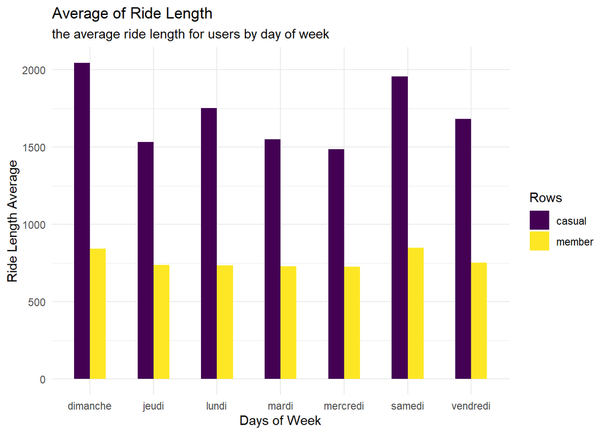

```r
bike_df_clean %>%
    group_by(columns = day_of_week, Rows = member_casual) %>%
    summarise(Values = mean(ride_length), .groups='drop') %>%
  arrange(Rows, columns)  %>%
  ggplot(mapping = aes(x = columns, y = Values, fill = Rows)) +
  geom_col(width=0.5, position = position_dodge(width=0.5)) +
  scale_fill_viridis_d() +
  labs(title = "Average of Ride Length",
       subtitle = "the average ride length for users by day of week",
       x = "Days of Week",
       y = "Ride Length Average") +
  theme_minimal()
```

Looking across weekdays, occasional users have the longest journey lengths on average.

- Calculate the number of rides for users by day_of_week by adding Count of trip_id to Values.

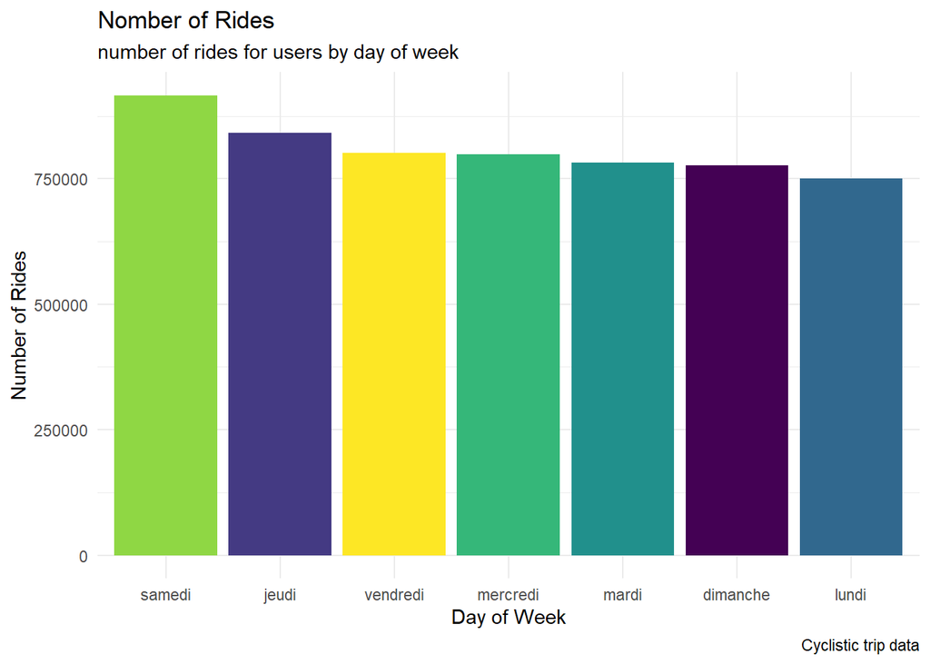

```r
bike_df_clean %>%
    group_by(columns = day_of_week) %>%
    summarise(Values = length(ride_id)) %>%
  ggplot(mapping = aes(x = reorder(columns, -Values), y = Values,
                       fill = columns)) +
  scale_fill_viridis_d() +
  geom_col(show.legend = FALSE) +
  #theme(legend.position="none") +
  labs(title = "Nomber of Rides",
       subtitle = "number of rides for users by day of week",
       x = "Day of Week",
       y = "Number of Rides",
       caption = "Cyclistic trip data") +
  theme_minimal()
```

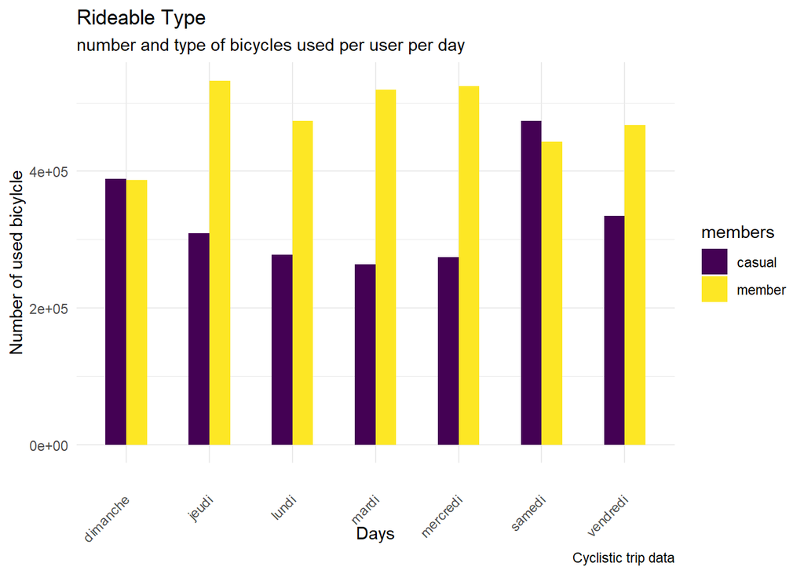

```r
bike_df_clean %>%
    group_by(Days = day_of_week, members = member_casual) %>%
    summarise(Values = length(rideable_type),.groups='drop') %>%
  ggplot(mapping = aes(x = Days , y = Values,
                       fill = members)) +
  scale_fill_viridis_d() +
  geom_col(width=0.5, position = position_dodge(width=0.5)) +
  #theme(legend.position="none") +
  labs(title = "Rideable Type",
       subtitle = "number and type of bicycles used per user per day",
       x = "Days",
       y = "Number of used bicylcle",
       caption = "Cyclistic trip data") +
  theme_minimal() +
  theme(axis.text.x = element_text(angle = 45, vjust = 0.5, hjust=1))
```

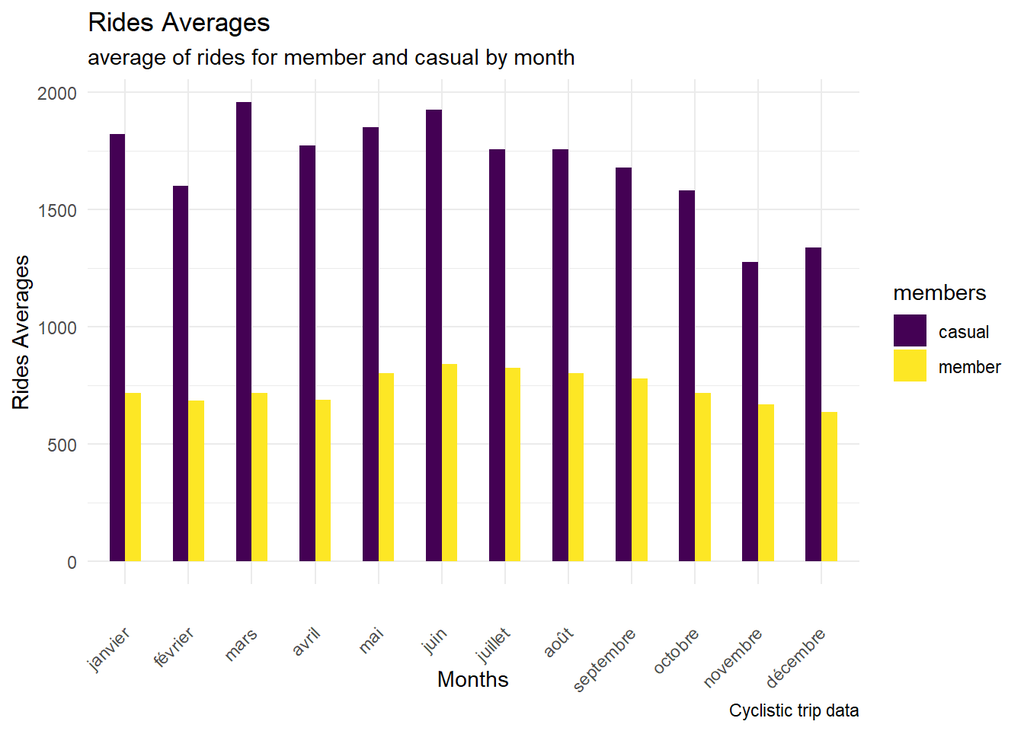

```r
# Reordered month correctly

bike_df_clean$month <- ordered(bike_df_clean$month,
                            levels=c("janvier", "février", "mars", "avril", "mai", "juin", "juillet", "août", "septembre", "octobre", "novembre", "décembre"))

bike_df_clean %>%
    group_by(month = month, members = member_casual) %>%
    summarise(Values = mean(ride_length),.groups='drop') %>%
  ggplot(mapping = aes(x = month , y = Values,
                       fill = members)) +
  scale_fill_viridis_d() +
  geom_col(width=0.5, position = position_dodge(width=0.5)) +
  #theme(legend.position="none") +
  labs(title = "Rides Averages",
       subtitle = "average of rides for member and casual by month",
       x = "Months",
       y = "Rides Averages",
       caption = "Cyclistic trip data") +
  theme_minimal() +
  theme(axis.text.x = element_text(angle = 45, vjust = 0.5, hjust=1))
```

**Create Maps for Geographic Visualization**

With the size of the dataset, we are going to map the number of casual and members in the month of march to make a comparison with ride length and the difference between the two groups of users by the **DuSable Lake Shore Dr & Monroe St** station *start_station_name*

For this analysis we are going to use `mapview` packages. `Mapview` is an R package that provides an interactive and easy-to-use interface for visualizing spatial data on interactive maps. The package is built on top of the leaflet JavaScript library, which allows for the creation of interactive and customizable web maps.

```r
# Loading the two geospatial packages to map data
library(mapview)
library(leafsync)
```

Use `filter` function to extract the data based on **casual** users the month the **type of bicycle** and the **start station name**

```r
casual_electric_SDGA <- bike_df_clean %>%
  filter(member_casual == "casual" & month == "mars" & rideable_type == "electric_bike" &
           start_station_name == "DuSable Lake Shore Dr & Monroe St") %>%
   select(member_casual, Longitude = start_lng, Latitude = start_lat, rideable_type, ride_length)
```

Use `filter` function to extract the data based on **members** users the month the **type of bicycle** and the **start station name**

```r
member_electric_SDGA <- bike_df_clean %>%
  filter(member_casual == "member" & month == "mars" & rideable_type == "electric_bike" &
           start_station_name == "DuSable Lake Shore Dr & Monroe St") %>%
  select(member_casual, Longitude = start_lng, Latitude = start_lat, rideable_type, ride_length)
```

```r
casual <- mapview(casual_electric_SDGA, xcol = "Longitude",
        ycol = "Latitude",
        crs = 4326, grid = FALSE,cex = "ride_length",
        zcol = "ride_length",
        #col.regions = "tomato",
        layer.name = "Casual",
        zoom = 19,
        use.layer.names = mapviewOptions(platform = "leaflet","CartoDB.DarkMatter"))


members <- mapview(member_electric_SDGA, xcol = "Longitude",
        ycol = "Latitude",
        crs = 4326, grid = FALSE,cex = "ride_length",
        zcol = "ride_length",
        #col.regions = "tomato",
        layer.name = "Members",
        zoom = 19,
        use.layer.names = mapviewOptions(platform = "leaflet","CartoDB.DarkMatter"))

sync(casual, members)
```

[interactive chart not shown]

Now it’s time to share with Stackholders.

### 0.1.7 Share

Now that you have performed your analysis and gained some insights into your data, create visualizations to share your findings. Moreno has reminded you that they should be sophisticated and polished in order to effectively communicate to the executive team. Use the following Case Study Roadmap as a guide:

**Key findings:**

In general we can see a situation where occasional users change the way our brain predicted the results.

For sharing this work with wi gonna use **Tableau**. **Tableau** is a powerful tool for data visualization and analysis, and it can be used in a wide variety of settings, from business and finance to healthcare and education. With its user-friendly interface and powerful features, Tableau has become a popular choice for data analysts, business intelligence professionals, and other users who need to work with data on a regular basis.